# Macro Regime-Adaptive Sector Rotation

FIN 452 — Supplementary Strategy

Author

Claude Code

Published

April 5, 2026

## 1. Strategy Overview

The pairs trading strategy in the main document assumes sector ETF spreads mean-revert. This assumption breaks down when macro regimes shift — which is precisely what caused most of its losses. This strategy flips the logic: instead of betting *against* macro-driven sector divergence, it bets *with* it.

The economic cycle rotates through regimes (expansion, peak, contraction, recovery). Each regime has historically favoured specific sectors. This strategy uses k-means clustering on six macroeconomic indicators to classify the current month’s regime, then allocates to the sectors that have historically outperformed in that regime. Long-only, monthly rebalancing, no shorting.

**Why this should beat SPY on a risk-adjusted basis:**

- Rotating into defensives (XLP, XLV, XLU) before recessions reduces drawdown
- Rotating into cyclicals (XLK, XLY, XLF) during expansions captures sector leadership
- The momentum filter prevents entering sectors in structural downtrends
- Long-only means no borrow costs, no KF instability, no margin requirements

## 2. Data

### 2.1 ETF Prices

### 2.2 Macro Indicators (FRED)

Six macroeconomic series are loaded via the FRED API through `tidyquant`. Together they characterise the current economic regime across four dimensions: credit conditions, growth momentum, labour market health, and inflation.

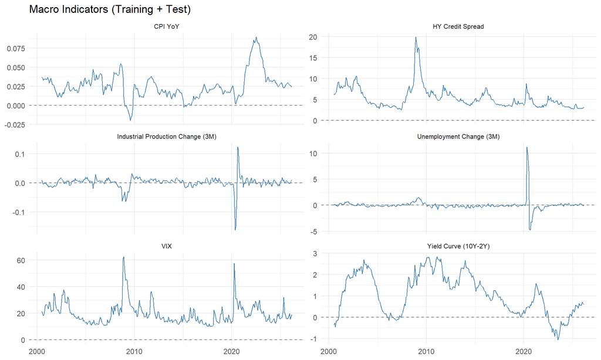

## 3. Regime Classification

### 3.1 Optimal K Selection

K is selected using the average silhouette score across k-means and hierarchical clustering, evaluated on the last month of the training period — the same approach as the main strategy. The macro cycle is theoretically 4-phase (expansion, peak, contraction, recovery), so k = 4 is the prior expectation.

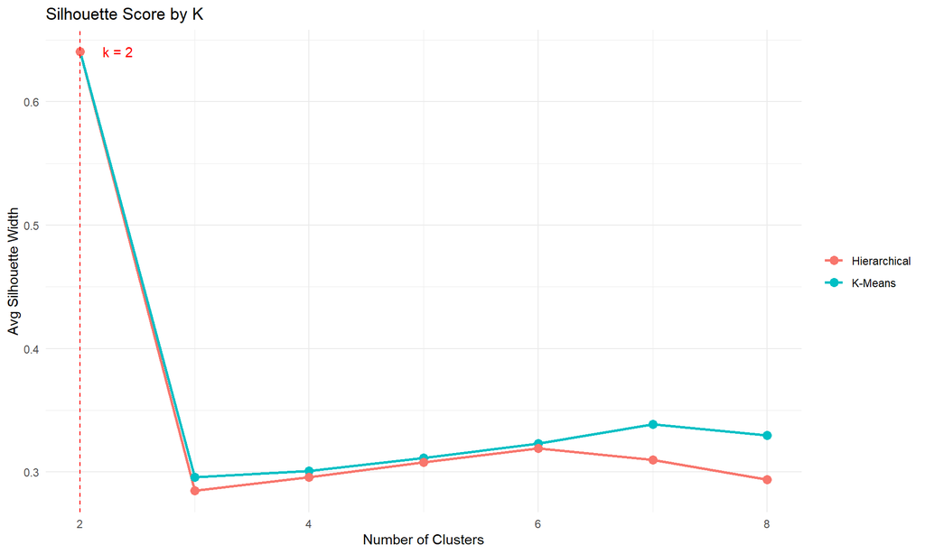

### 3.2 Regime Characterisation

Macro Regime Profiles (Training Period)

| regime | n_months | yield_curve | hy_spread | vix | unrate_chg3 | cpi_yoy | indpro_chg3 | interpretation |
| --- | --- | --- | --- | --- | --- | --- | --- | --- |
| 1 | 14 | 1.62 | 12.92 | 42.99 | 2.76 | 0.01 | −0.06 | Contraction (labour deteriorating) |
| 2 | 289 | 1.01 | 5.12 | 18.96 | −0.13 | 0.03 | 0.00 | Expansion (low stress, risk-on) |

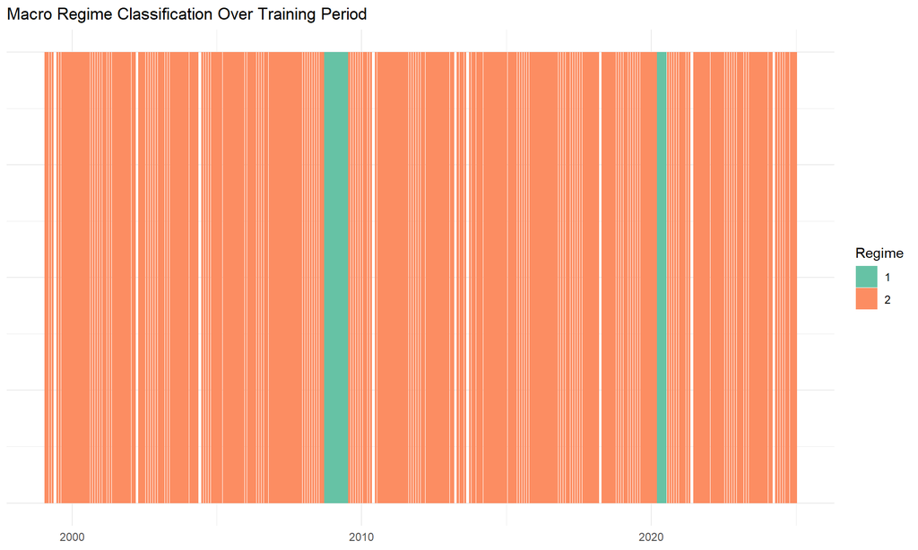

## 4. Sector Selection & Weighting

At each month-end rebalancing date, the strategy:

1. Clusters all macro history up to that date (expanding window, re-clustered monthly)
2. Identifies the current month’s regime
3. Computes average next-month sector returns for each regime using only past data
4. Selects the top 4 sectors by expected regime return
5. Applies a momentum gate: a sector must be above its 10-month price SMA to be eligible. If fewer than 2 sectors pass, the filter is relaxed (regime signal dominates)
6. Weights eligible sectors by inverse 3-month realised volatility

## 5. Backtest

## 6. Performance Results

### 6.1 Metrics

Macro Rotation Strategy vs SPY

| Period | Cum. Return | Sharpe | Omega Sharpe | Max Drawdown | SPY Sharpe | SPY Corr |
| --- | --- | --- | --- | --- | --- | --- |
| Training | 513.4% | 0.430 | 0.097 | 53.2% | 0.410 | 0.884 |
| Test | −2.8% | −0.133 | −0.008 | 23.2% | 0.542 | 0.883 |

### 6.2 Equity Curves

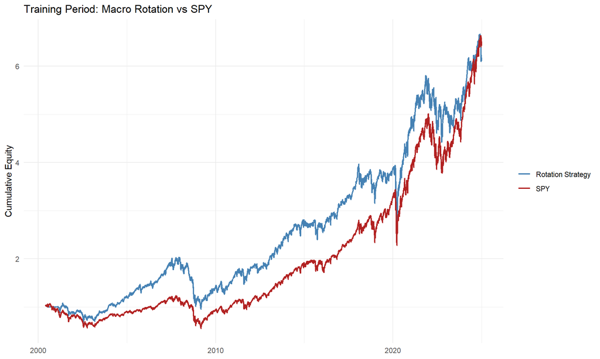

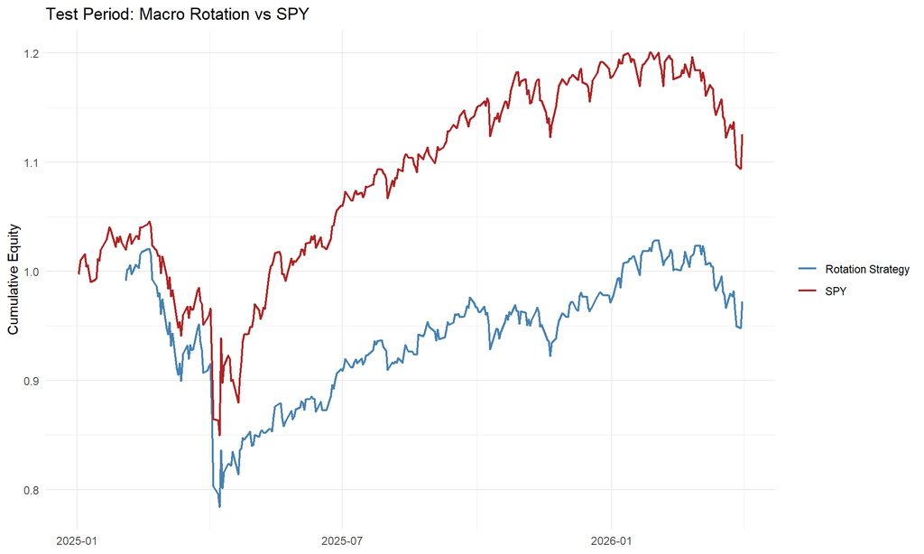

### 6.4 Regime Allocation Over Time

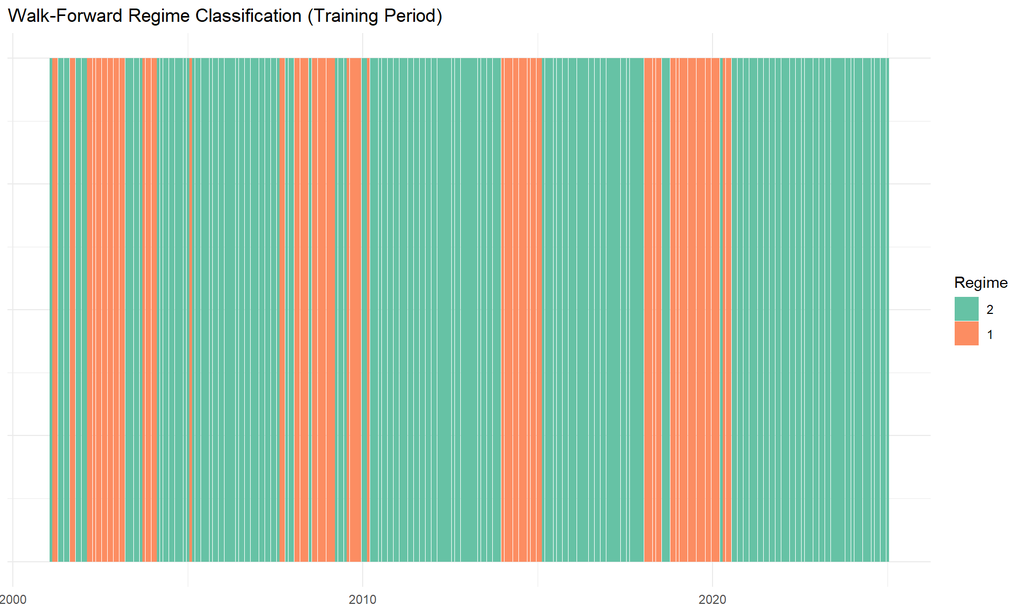

## 7. Discussion

**Why this strategy is structured this way:**

The key design choice is using *macro state* rather than *price spread history* to generate signals. The pairs trading strategy in the main document failed because it assumed sector spreads mean-revert — which they do not do during structural macro shifts (QE-driven sector divergence post-2008, tariff shock in 2025). This strategy does not fight macro regimes; it reads them and allocates accordingly.

**The clustering role:** k-means on macro indicators groups months with similar macro environments. The cluster label at time t summarises the current regime without any model assumptions about what each regime means — the data determines the groupings. The regime-return mapping then learns empirically which sectors outperformed historically in each macro state.

**What can still go wrong:**

- **Regime mislabelling:** k-means clustering on expanding data can reassign historical labels as new data arrives. The regime at month t+1 may be classified differently next month when more data is available. The strategy uses only the current labelling, so there is some instability.
- **Regime transitions:** At the turning point between regimes (e.g., early 2008), the model will lag by one month because it sees the old regime until end-of-month data updates.
- **Survivorship in sector ETFs:** The composition of each sector ETF changes over time. XLK in 2000 was dominated by telecoms; by 2020 it is Apple and Microsoft. The sector behaviour the model is trained on reflects different underlying stocks.
- **2025 tariff shock:** A high-VIX, wide-credit-spread month should classify as a contraction regime and rotate into XLP/XLV/XLU. Whether the monthly rebalancing frequency was fast enough to avoid most of the April 2025 drawdown depends on when the macro indicators crossed the regime boundary.